# Rna-seq analysis

# Differential expression

Давайте посмотрим, как выглядят результаты дифференциальной экспрессии и отсортируем их по статистике.

```r
res <- results(dds)
res
```

```
## log2 fold change (MAP): cells cell type: Regulatory T cells vs cell type: Conventional CD4 T cells
## Wald test p-value: cells cell type: Regulatory T cells vs cell type: Conventional CD4 T cells
## DataFrame with 33061 rows and 6 columns
##                   baseMean log2FoldChange     lfcSE       stat       pvalue         padj
##                  <numeric>      <numeric> <numeric>  <numeric>    <numeric>    <numeric>
## ENSG00000000003 423.163296      0.6353820 0.4920649  1.2912564 1.966148e-01 4.115223e-01
## ENSG00000000005   8.893115     -0.1407287 0.5653427 -0.2489264 8.034177e-01 9.019086e-01
## ENSG00000000419 848.545987      0.1917925 0.1553810  1.2343366 2.170775e-01 4.367093e-01
## ENSG00000000457 418.002766     -0.2072443 0.2863086 -0.7238491 4.691584e-01 6.782815e-01
## ENSG00000000460 255.889945      1.0303879 0.2109222  4.8851554 1.033473e-06 5.029308e-05
## ...                    ...            ...       ...        ...          ...          ...
## ENSG00000273487  2.0044609     -1.1041178 0.5613033 -1.9670608   0.04917621    0.1730004
## ENSG00000273488  2.0018329     -0.1237904 0.5938888 -0.2084404   0.83488512    0.9185921
## ENSG00000273489  2.0643945     -0.8703608 0.5899502 -1.4753122   0.14012862    0.3347996
## ENSG00000273492  7.1719267      0.1105504 0.4900293  0.2255996   0.82151289    0.9126498
## ENSG00000273493  0.7341817     -0.5280960 0.5938689 -0.8892466   0.37387054           NA
```

```r
mcols(res)$description
```

```
## [1] "mean of normalized counts for all samples"
## [2] "log2 fold change (MAP): cells cell type: Regulatory T cells vs cell type: Conventional CD4 T cells"
## [3] "standard error: cells cell type: Regulatory T cells vs cell type: Conventional CD4 T cells"
## [4] "Wald statistic: cells cell type: Regulatory T cells vs cell type: Conventional CD4 T cells"
## [5] "Wald test p-value: cells cell type: Regulatory T cells vs cell type: Conventional CD4 T cells"
## [6] "BH adjusted p-values"
```

```r
res <- res[order(res[, 4]), ]    # иногда в p-value будет NA потому что экспрессия и разница экспрессии очень низкая
res
```

```
## log2 fold change (MAP): cells cell type: Regulatory T cells vs cell type: Conventional CD4 T cells
## Wald test p-value: cells cell type: Regulatory T cells vs cell type: Conventional CD4 T cells
## DataFrame with 33061 rows and 6 columns
##                   baseMean log2FoldChange     lfcSE      stat       pvalue         padj
##                  <numeric>      <numeric> <numeric> <numeric>    <numeric>    <numeric>
## ENSG00000161570 8799.11575      -4.017998 0.2814404 -14.27655 3.063996e-46 1.956759e-42
## ENSG00000113088  652.42368      -4.936846 0.4267500 -11.56847 5.953274e-31 1.174444e-27
## ENSG00000211696   12.63903      -5.008570 0.4600610 -10.88675 1.333098e-27 2.279243e-24
## ENSG00000026751  228.64205      -3.577999 0.3297970 -10.84910 2.014058e-27 3.228283e-24
## ENSG00000129277 2542.27971      -3.779444 0.3589640 -10.52876 6.366981e-26 9.071532e-23
## ...                    ...            ...       ...       ...          ...          ...
## ENSG00000134460  3912.4839       3.752689 0.2779827  13.49972 1.569682e-41 6.709344e-38
## ENSG00000049249  2760.5357       4.582526 0.3213268  14.26126 3.814940e-46 1.956759e-42
## ENSG00000228168   619.2113       4.798208 0.3207362  14.95998 1.340576e-50 1.146013e-46
## ENSG00000049768  1796.1161       5.174400 0.3199144  16.17433 7.652839e-59 9.813236e-55
## ENSG00000179934  3177.8601       4.675938 0.2868261  16.30235 9.497680e-60 2.435775e-55
```

```r
res_2 <- results(dds_2)
res_2
```

```
## log2 fold change (MAP): tissue tissue: NBP vs tissue: breast tumor
## Wald test p-value: tissue tissue: NBP vs tissue: breast tumor
## DataFrame with 33061 rows and 6 columns
##                   baseMean log2FoldChange     lfcSE        stat    pvalue      padj
##                  <numeric>      <numeric> <numeric>   <numeric> <numeric> <numeric>
## ENSG00000000003 423.163296     0.78625088 0.4866650   1.6155896 0.1061831 0.4545499
## ENSG00000000005   8.893115     0.16640264 0.4961056   0.3354178 0.7373099 0.9256733
## ENSG00000000419 848.545987    -0.09463599 0.1632760  -0.5796075 0.5621793 0.8532446
## ENSG00000000457 418.002766    -0.22775876 0.2968459  -0.7672626 0.4429254 0.7918868
## ENSG00000000460 255.889945    -0.27895162 0.2206896  -1.2639999 0.2062301 0.6033982
## ...                    ...            ...       ...         ...       ...       ...
## ENSG00000273487  2.0044609     0.06145034 0.5368087  0.11447344 0.9088625        NA
## ENSG00000273488  2.0018329    -0.05206796 0.5435299 -0.09579594 0.9236826        NA
## ENSG00000273489  2.0643945     0.40513733 0.5311731  0.76272185 0.4456293        NA
## ENSG00000273492  7.1719267    -0.36994113 0.4859536 -0.76126838 0.4464968 0.7944792
## ENSG00000273493  0.7341817     0.01488372 0.5438816  0.02736574 0.9781680        NA
```

```r
mcols(res_2)$description
```

```
## [1] "mean of normalized counts for all samples"
## [2] "log2 fold change (MAP): tissue tissue: NBP vs tissue: breast tumor"
## [3] "standard error: tissue tissue: NBP vs tissue: breast tumor"
## [4] "Wald statistic: tissue tissue: NBP vs tissue: breast tumor"
## [5] "Wald test p-value: tissue tissue: NBP vs tissue: breast tumor"
## [6] "BH adjusted p-values"
```

```r
res_2 <- res_2[order(res_2[, 4]), ]    # иногда в p-value будет NA потому что экспрессия и разница экспрессии очень низкая
res_2
```

```
## log2 fold change (MAP): tissue tissue: NBP vs tissue: breast tumor
## Wald test p-value: tissue tissue: NBP vs tissue: breast tumor
## DataFrame with 33061 rows and 6 columns
##                   baseMean log2FoldChange     lfcSE      stat       pvalue         padj
##                  <numeric>      <numeric> <numeric> <numeric>    <numeric>    <numeric>
## ENSG00000204388  842.42959      -3.435718 0.4203046 -8.174353 2.974572e-16 6.349819e-12
## ENSG00000204389  919.00612      -2.863978 0.4044113 -7.081845 1.422475e-12 8.188949e-09
## ENSG00000025708  218.95342      -1.972001 0.2788723 -7.071340 1.534445e-12 8.188949e-09
## ENSG00000267757   15.08424      -3.233544 0.4681014 -6.907785 4.922798e-12 2.101739e-08
## ENSG00000095794 3144.82203      -1.685860 0.2616693 -6.442713 1.173565e-10 3.578871e-07
## ...                    ...            ...       ...       ...          ...          ...
## ENSG00000211448  288.47682       3.353188 0.5388359  6.223023           NA           NA
## ENSG00000091138  367.67399       3.466986 0.5466239  6.342543           NA           NA
## ENSG00000152931   42.34677       2.490814 0.3752565  6.637631 3.187642e-11 1.134110e-07
## ENSG00000198744  234.46533       3.689758 0.4964139  7.432825           NA           NA
## ENSG00000162896  508.10383       3.399408 0.4439395  7.657367 1.897837e-14 2.025656e-10
```

Самый обычный способ визуализировать данные дифф.экспрессии – это volcano plot. По оси x мы будем откладывать log fold change, а по y - adjusted p value.

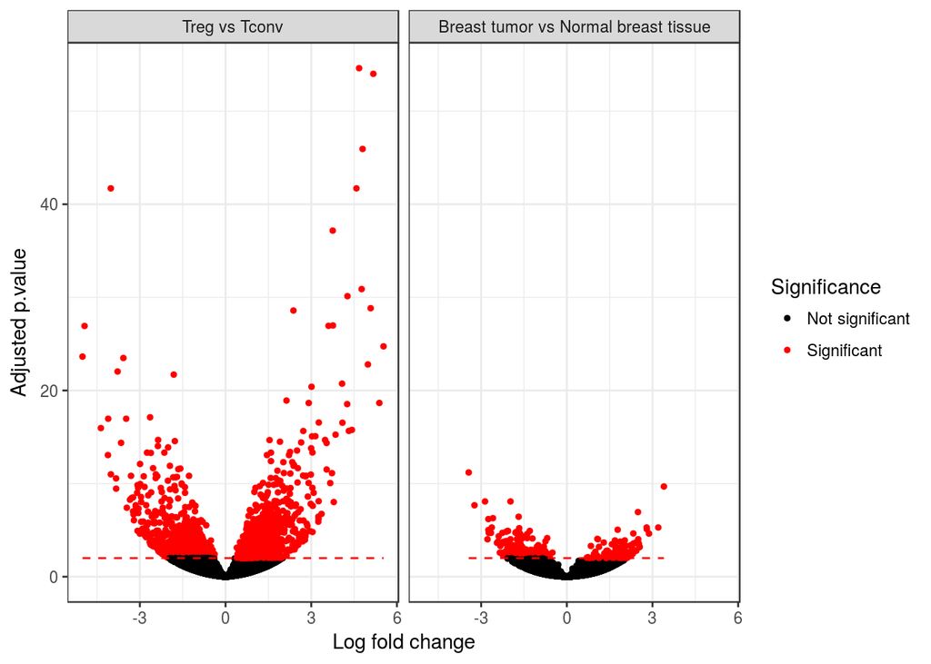

```r
gdata <- na.omit(data.frame(
  x=res$log2FoldChange,
  y=-log10(res$padj),
  k=rep("Treg vs Tconv", length(res$log2FoldChange))
))
gdata_2 <- na.omit(data.frame(
  x=res_2$log2FoldChange,
  y=-log10(res_2$padj),
  k=rep("Breast tumor vs Normal breast tissue", length(res$log2FoldChange))
))
gdata <- rbind(gdata, gdata_2)

gdata$Significance <- as.factor(ifelse(gdata$y < 2, "Not significant", "Significant"))

ggplot(data=gdata, aes(x=x, y=y, col=Significance)) +
  geom_point(size=1) + theme_bw() + facet_grid(. ~ k) +
  xlab("Log fold change") +
  ylab("Adjusted p.value") +
  scale_colour_manual(values = c("black", "red")) +
  geom_line(aes(y = 2), colour = "red", linetype="dashed")
```

Также мы можем построить тепловую карту отсортировав гены по статистике

```r
counts.norm <- counts(dds, normalized=TRUE)
png("heatmap_large.png", width=6, height=20, units="in", res=300)

to_visualise <- counts.norm[rownames(res), order(conditions[, 2])]
to_visualise <- t(apply(to_visualise, 1, function(r) {
  (r - min(r)) / (max(r) - min(r))
}))

pheatmap(to_visualise,
         show_rownames = F, cluster_rows = F,
         cluster_cols=F,
         annotation_col = conditions)
dev.off()
```

# clusterProfiler

Библиотека содержит в себе большое количество утилит для аннотации наборов генов.

```r
genes <- bitr(rownames(res),
              fromType = "ENSEMBL",
              toType = c("ENTREZID", "SYMBOL"),
              OrgDb = org.Hs.eg.db)
head(genes)
```

```
##            ENSEMBL ENTREZID SYMBOL
## 2  ENSG00000113088     3003   GZMK
## 4  ENSG00000026751    57823 SLAMF7
## 6  ENSG00000133302    84250   SLF1
## 7  ENSG00000164398    23305  ACSL6
## 8  ENSG00000145649     3001   GZMA
## 10 ENSG00000100450     2999   GZMH
```

```r
genes <- genes[!duplicated(genes[, 1]), ]  # оставим только первую строчку
rownames(genes) <- genes[, 1]
res$ENSEMBL <- rownames(res)

merged <- merge(as.data.frame(res), genes)
head(merged)
```

```
##           ENSEMBL   baseMean log2FoldChange     lfcSE       stat       pvalue         padj ENTREZID   SYMBOL
## 1 ENSG00000000003 423.163296     0.63538202 0.4920649  1.2912564 1.966148e-01 4.115223e-01     7105   TSPAN6
## 2 ENSG00000000005   8.893115    -0.14072871 0.5653427 -0.2489264 8.034177e-01 9.019086e-01    64102     TNMD
## 3 ENSG00000000419 848.545987     0.19179247 0.1553810  1.2343366 2.170775e-01 4.367093e-01     8813     DPM1
## 4 ENSG00000000457 418.002766    -0.20724425 0.2863086 -0.7238491 4.691584e-01 6.782815e-01    57147    SCYL3
## 5 ENSG00000000460 255.889945     1.03038790 0.2109222  4.8851554 1.033473e-06 5.029308e-05    55732 C1orf112
## 6 ENSG00000000938  31.380430     0.05804885 0.5780237  0.1004264 9.200058e-01 9.640626e-01     2268      FGR
```

Давайте что-нибудь узнаем о дифф.экспрессированных генах!

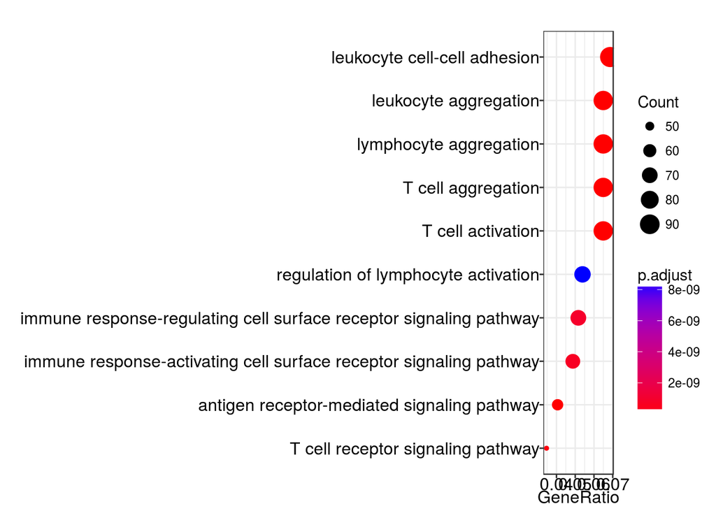

```r
diffExpGenes <- merged[which(merged$padj < 0.01), 8] # возьмем только дифф экспресс гены
universe <- as.character(merged[, 8])

ego <- enrichGO(gene          = diffExpGenes,
                universe      = universe,
                OrgDb         = org.Hs.eg.db,
                ont           = "BP", # указываем нужную базу данных (Biological Processes)
                pAdjustMethod = "BH",
                pvalueCutoff  = 0.01,
                qvalueCutoff  = 0.05,
        readable      = TRUE)
# head(ego)
dotplot(ego)
```

Построим свой heatmap с генами из нужного пасвэя

```r
kkeys <- keys(org.Hs.eg.db, keytype="ENSEMBL")
goAnno <- AnnotationDbi::select(org.Hs.eg.db, keys=kkeys,
                                keytype="ENSEMBL", columns=c("GOALL", "ONTOLOGYALL", "SYMBOL"))
```

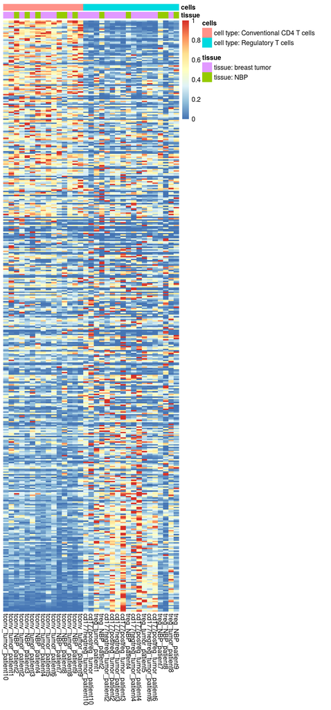

```r
goAnno <- tbl_df(goAnno)
goAnno <- filter(goAnno, GOALL=="GO:0007159")
# or you can pick ENTREZ, or SYMBOL, or whatever you want

genesToVisualise <- as.vector(goAnno$ENSEMBL)

to_visualise <- counts.norm[rownames(res[order(res[, 4]),]), order(conditions[, 2])]
vis_fin <- to_visualise[row.names(to_visualise) %in% genesToVisualise ,]
vis_fin <- t(apply(vis_fin, 1, function(r) {
  (r - min(r)) / (max(r) - min(r))
}))

pheatmap(vis_fin,
         show_rownames = F, cluster_rows = F,
         cluster_cols=F,
         annotation_col = conditions)
```

#Диаграммы Венна для дифф.экспрессированых генов в двух сравнениях

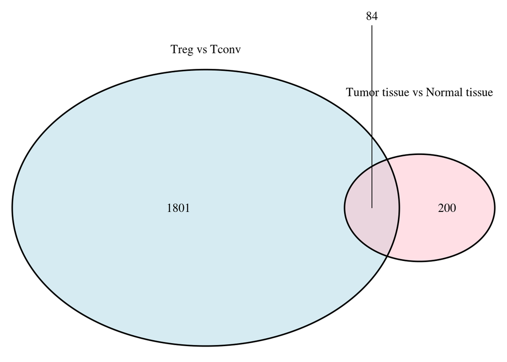

```
## (polygon[GRID.polygon.482], polygon[GRID.polygon.483], polygon[GRID.polygon.484], polygon[GRID.polygon.485], text[GRID.text.486], text[GRID.text.487], text[GRID.text.488], lines[GRID.lines.489], text[GRID.text.490], text[GRID.text.491])
```

```r
resa <- na.omit(res)
resa_2 <- na.omit(res_2)
commonLetters <- intersect(rownames(resa[resa$padj<0.01,]), rownames(resa_2[resa_2$padj<0.01,]))
draw.pairwise.venn(nrow(resa[resa$padj<0.01,]), nrow(resa_2[resa_2$padj<0.01,]), length(commonLetters),
                   category = c("Treg vs Tconv", "Tumor tissue vs Normal tissue"),
                   fill = c("light blue", "pink"),
                   cat.pos = c(0, 0),
                   cat.dist = c(0.03, 0.09))
```